# BANA 4137 Project 3

Leah Ngan Lai

2020-12-01

**Load packages**

```r
# Load useful packages
#install.packages("forecast")
#install.packages("fpp2")
library(forecast)
library(dplyr)
library(ggplot2)
library(readr)
library(zoo)
library(lubridate)
library(RColorBrewer)
```

# PART 1: Flights - First dataset

### 1.1 Read data files

```r
setwd("~/Downloads/BANA 4137")

# Read data files
flights = read.csv("CVG_Flights.csv", header = TRUE, stringsAsFactors = FALSE, na.strings = "")
airlines = read.csv("airlines.csv", header = TRUE, stringsAsFactors = FALSE, na.strings = "")
airports = read.csv("airports.csv", header = TRUE, stringsAsFactors = FALSE, na.strings = "")
```

### 1.2 Merge into big dataframe

```r
first_dataframe <- left_join(flights,
                             airlines,
                             by=c("AIRLINE"="IATA_CODE"))
total_dataframe <- left_join(flights,
                             airports,
                             by=c("ORIGIN_AIRPORT"="IATA_CODE"))
names(total_dataframe)
```

```
##  [1] "FLIGHT_DATE"         "AIRLINE"             "FLIGHT_NUMBER"
##  [4] "ORIGIN_AIRPORT"      "DESTINATION_AIRPORT" "SCHEDULED_DEPARTURE"
##  [7] "DEPARTURE_TIME"      "DEPARTURE_DELAY"     "TAXI_OUT"
## [10] "WHEELS_OFF"          "SCHEDULED_TIME"      "ELAPSED_TIME"
## [13] "AIR_TIME"            "DISTANCE"            "WHEELS_ON"
## [16] "TAXI_IN"             "SCHEDULED_ARRIVAL"   "ARRIVAL_TIME"
## [19] "ARRIVAL_DELAY"       "DIVERTED"            "CANCELLED"
## [22] "CANCELLATION_REASON" "AIR_SYSTEM_DELAY"    "SECURITY_DELAY"
## [25] "AIRLINE_DELAY"       "LATE_AIRCRAFT_DELAY" "WEATHER_DELAY"
## [28] "AIRPORT"             "CITY"                "STATE"
## [31] "COUNTRY"             "LATITUDE"            "LONGITUDE"
```

### 1.3 Question 1

**What is the arrival delay in the first three month of 2015?** *Observation: Looking into the visualization below, we can see that the highest delay (700 mins) was before March. From this, we can think about the reason why it was like that. We can come up with the new question later whether the delay time happening because of the bad weather before March.And there are a pattern before March for the delay.*

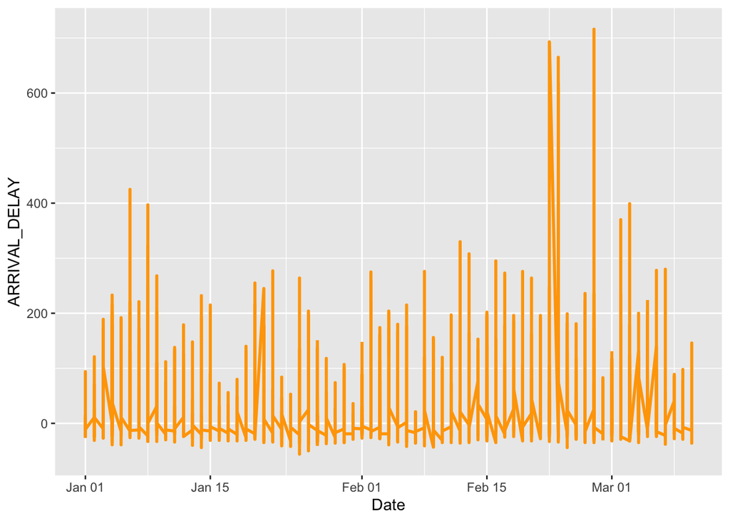

```r
d<- as.POSIXct(total_dataframe$FLIGHT_DATE, format = "%m/%d/%Y")
total_dataframe$dm <- format(d, "%m")

p <- ggplot(total_dataframe, aes(x=d, y=ARRIVAL_DELAY)) +
  geom_line(color='orange',size=1) +
  xlab("Date")
p
```

### 1.4 Question 2

**What is the density of the highest elapsed time?** *Observation:Looking into the visualization below, we can notice that the highest elapsed time was around 60-80 minutes or 120-140 minutes at the density around 0.009 - 0.0100. From this, we can relate to the real situation in real life, most of the time, flights get delayed around 1-2 hours. This can be one of the reasons for that.*

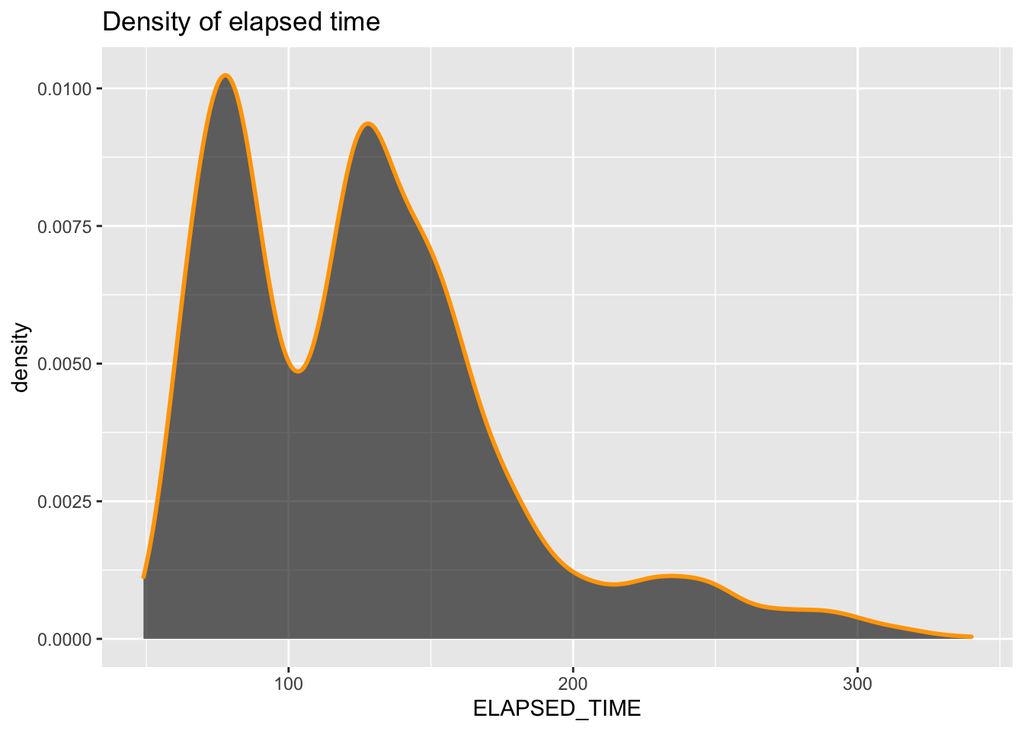

```r
np <- ggplot(data=total_dataframe,aes(x=ELAPSED_TIME, xlab = 'elapsed time')) +
  geom_density(color = "orange",fill="black",alpha=0.6,size=1,adjust=1) +
  ggtitle("Density of elapsed time")
np
```

### 1.5 Question 3

**What is the median distance travel of each airlines ? Compare the highest median with the lowest median?** *Observation:In the visualization below, we can see that the higest median distance is from F9(Frontier Airlines Inc.) airline, and the lowest one is from OO(Skywest Airlines Inc.). From this, it can explain that maybe F9 is having more destinations or longer distance between location than OO throughout the United State.*

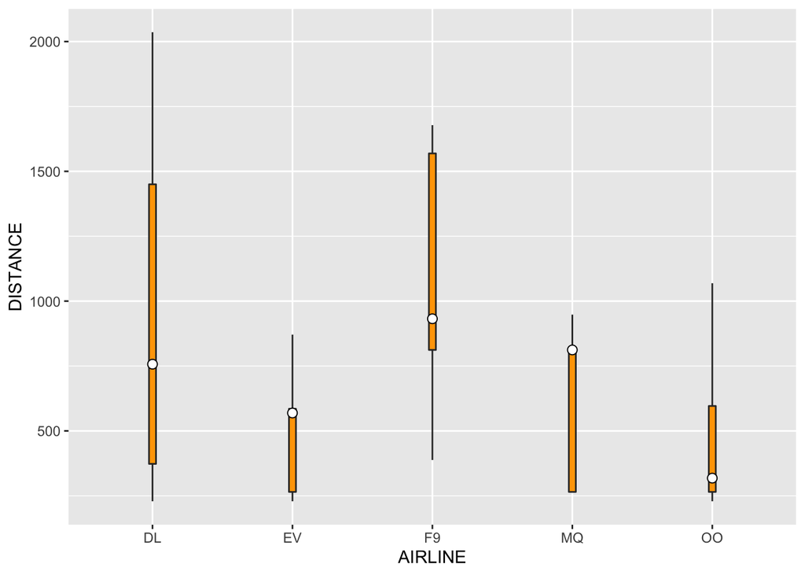

```r
ggplot(total_dataframe,aes(AIRLINE,DISTANCE,fill=AIRLINE))+
  geom_boxplot(width=0.05,fill="orange",outlier.color = NA)+
  stat_summary(fun = median,geom = "point",fill="white",size=2.5,shape=21)
```

# PART 2: College - Second dataset

```r
college <- read_csv("college.csv")
```

### 2.1: Read the data names

```r
names(college)
```

```
##  [1] "id"                 "name"               "city"
##  [4] "state"              "region"             "highest_degree"
##  [7] "control"            "gender"             "admission_rate"
## [10] "sat_avg"            "undergrads"         "tuition"
## [13] "faculty_salary_avg" "loan_default_rate"  "median_debt"
## [16] "lon"                "lat"
```

```r
summary(college)
```

```
##        id             name               city              state
##  Min.   :100654   Length:1269        Length:1269        Length:1269
##  1st Qu.:153250   Class :character   Class :character   Class :character
##  Median :186283   Mode  :character   Mode  :character   Mode  :character
##  Mean   :186988
##  3rd Qu.:215284
##  Max.   :484905
##     region          highest_degree       control             gender
##  Length:1269        Length:1269        Length:1269        Length:1269
##  Class :character   Class :character   Class :character   Class :character
##  Mode  :character   Mode  :character   Mode  :character   Mode  :character
##
##
##
##  admission_rate      sat_avg       undergrads       tuition
##  Min.   :0.0509   Min.   : 720   Min.   :   47   Min.   : 2732
##  1st Qu.:0.5339   1st Qu.: 973   1st Qu.: 1296   1st Qu.: 8970
##  Median :0.6687   Median :1040   Median : 2556   Median :20000
##  Mean   :0.6501   Mean   :1060   Mean   : 5629   Mean   :21025
##  3rd Qu.:0.7859   3rd Qu.:1120   3rd Qu.: 6715   3rd Qu.:30364
##  Max.   :1.0000   Max.   :1545   Max.   :52280   Max.   :51008
##  faculty_salary_avg loan_default_rate   median_debt         lon
##  Min.   : 1451      Length:1269        Min.   : 6056   Min.   :-157.92
##  1st Qu.: 6191      Class :character   1st Qu.:21250   1st Qu.: -94.17
##  Median : 7272      Mode  :character   Median :24588   Median : -84.89
##  Mean   : 7656                         Mean   :23483   Mean   : -88.29
##  3rd Qu.: 8671                         3rd Qu.:27000   3rd Qu.: -78.63
##  Max.   :20650                         Max.   :41000   Max.   : -68.59
##       lat
##  Min.   :19.71
##  1st Qu.:35.22
##  Median :39.74
##  Mean   :38.61
##  3rd Qu.:41.81
##  Max.   :61.22
```

### 2.2 Question 1

**What is the sat_avg changing vs admission_rate ?** *Observation:Looking at the visualization below, we can see that a massive number of students scored their SAT from 850 to 1150. But it tends to decrease after that because the exam is challenging. While doing this series, I can feel that it is not the right way to display these two variables into a time series. Lesson-learn: We understand that variable characteristics are really important.*

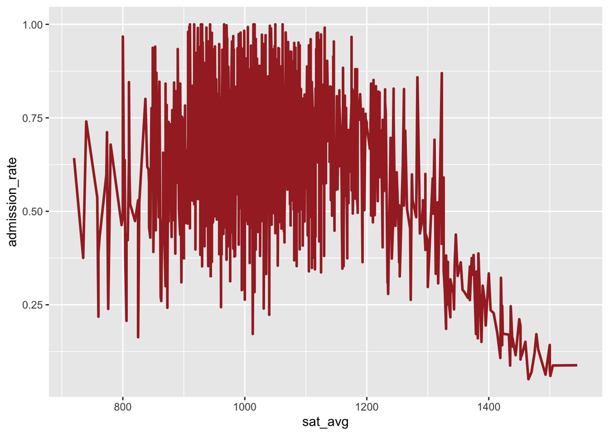

```r
p <- ggplot(college, aes(x=sat_avg, y=admission_rate)) +
  geom_line(color='brown',size=1) +
  xlab("sat_avg")
p
```

### 2.3 Question 2:

**What is the difference for tuition between region in the US ? Compare them** *Observation:Looking into the visualization below, we can see that the Northeast is having the highest median tuition. It makes sense because there are well-known private colleges in Boston, New York like Harvard, MIT, NYU. Then the Midwest, it can be guessed as UPen, or University of Chicago, or Case Western University.*

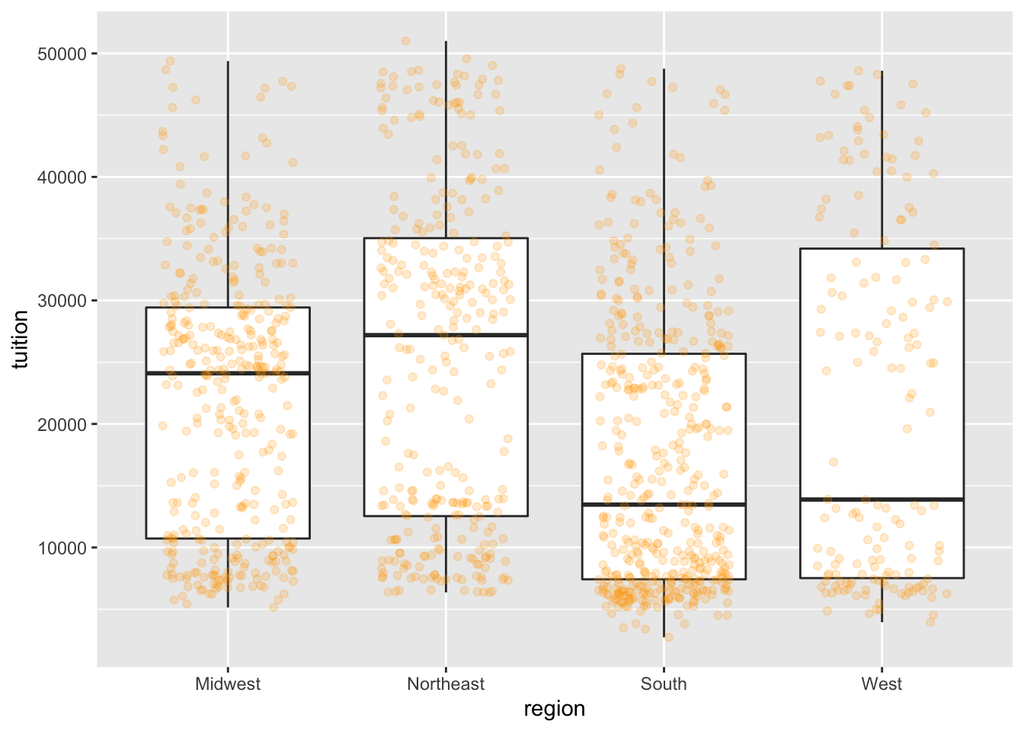

```r
ggplot(college, aes(x=region,y=tuition)) +
  geom_boxplot() +
  geom_jitter(width=0.3, alpha =0.2,color="orange")
```

### 2.4 Question 3

**What is the density of the highest region and why?** *Observation:Looking into the data visualization below, it is fascinating to see that the highest density for faculty salary avg is the Midwest region and the second-highest in the South region. But the highest salary is from the West and Northeast. For the highest salary, we can explain that maybe their tuition is expensive (with above explanation) to afford to pay more for the faculty.*

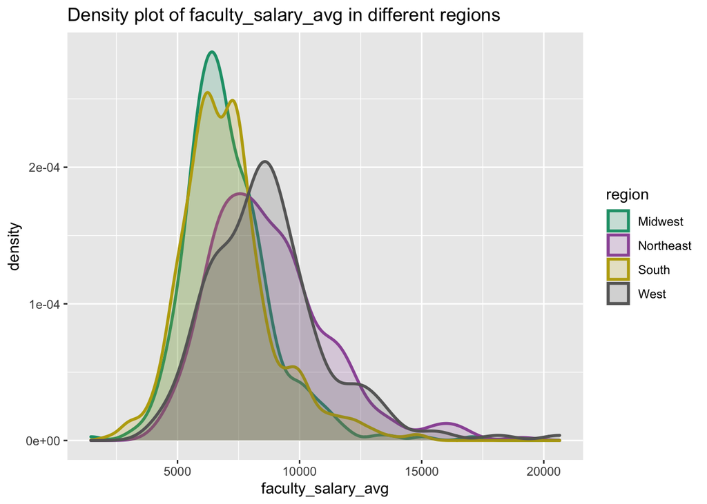

```r
ggplot(data=college,aes(x=faculty_salary_avg,color=region,fill=region))+ geom_density(alpha = 0.2,size=1,linetype="solid")+
  scale_color_manual(values =colorRampPalette(brewer.pal(8,"Dark2"))(4))+
  scale_fill_manual(values =colorRampPalette(brewer.pal(8,"Dark2"))(4))+
ggtitle("Density plot of faculty_salary_avg in different regions")
```